# The Population Genetics of GWAS

Bruce J. Cochrane

July 14 2015

## Introduction

So what is a GWAS (Genome-wide Association Study) anyway? In principle, it is really nothing more than a case-control study, a method with a rich history in epidemiology. Let’s think of a hypothetical example. Suppose that, in a population, there is a group of individuals that suffer from some metabolic disorder, and as an investigator, you wish to determine its cause. To do so, you identify individuals with the disorders (“cases”) and a similar number without it (“controls”), and make a series of measurements on them. For instance, in this case, you might compare diet, weight, or other variables you suspect might cause the disorder and look for statistically significant differences in the mean values you’ve determined for the case and control populations.

In a GWAS, the comparison between case and control populations is not phenotypic, as in our hypothetical case, but rather genotypic. The logic, on the surface, is rather simple:

1. Cases and controls are identified.
2. The genotypes of those individuals are determined at as many variable sites in the genome (usually Single Nucleotide Polymorphisms, or SNPs).
3. Statistical analysis is used to identify variants that differ in frequency between the two populations.
4. Based on knowledge of the genome, it may be possible to identify candidate loci (genes) that are responsible for the trait or disorder being examined.

Sounds simple, right? Well, not really. Consider the following questions:

1. Is the trait always the result of the same allele?
2. If it is, how strongly can we infer the presence of that allele based on its association with other linked markers?
3. If we can associate the disease allele with other markers in a particular population, can we then apply our results to other populations. In other words, are the results of a GWAS performed in, for example, an Asian population, directly applicable to a Northern European one?
4. Most importantly, **is an observed association between a trait and a set of genetic markers truly causative?**

Many of these issues are covered in depth by Visscher et al. (2012), and I strongly recommend that paper to the interested reader. What follows here is just a brief overview, designed to introduce some of the issues in a more simple fashion. We will focus on the first three questions, as those are the ones that lie largely within the realm of genetic inference.

## Relevant Population Genetics Principles

Foulkes (2009)

### Population Differentiation

## HAPMAP - A Quick Overview

Altshuler et al. (2010)

## Some Examples

For what should be obvious reasons, the real raw GWAS data are not publicly available. As an alternative, we will use simulated data, generated with the program hapgen2 (Su, Marchini, and Donnelly (2011)). What this program does is to generate simulated case-control populations, given the location(s) of one or more trait-associated SNPs, the phenotypic effect of a particular allele, the distribution of haplotypes, and the recombination rates among SNPs, from an overall population from which the hypothetical cases and controls were sampled. With these data, the program can use SNP allele frequencies and patterns of linkage disequilibrium in that population to realistically model what the case and control haplotypes would look like.

### Case 1. A low frequency allele in Asia

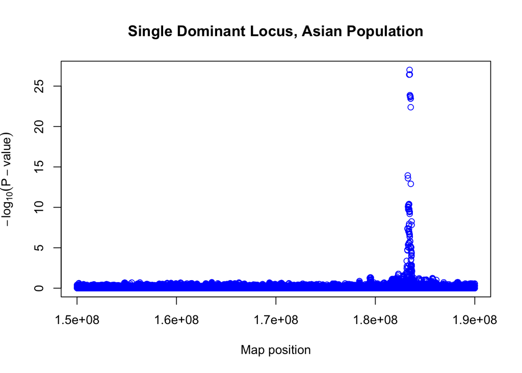

Although somewhat cryptically labelled, in fact, the y value on this plot is analogous to a lod score - it gives a measure of the likelihood that there is a contributing gene at a particular position relative to the likelihood that there is not. So it’s pretty clear that there is a gene somewhere between 1.8 X 10<sup>8</sup> ans 1.9 X 10<sup>8</sup>.

```
## Summary for top 15 results, sorted by P1df
```

[output not shown]

There is a chance that one of these SNPs is in fact the disease causing one, but if so, it would be lucky indeed to have found it. What we do have is a set of snps that demonstrate strong association for the phenotype. So now we have to identify the specific haplotype associated with the disorder. We’ll do this in two steps. First, we will display the bases that are segregating at each of the sites associated with the disease:

```
## Summary for top 20 results, sorted by Pc1df
```

```
##            bases
## rs41377350    GT
## rs6698620     AG
## rs10494582    AG
## rs16823862    TC
## rs16823869    CT
## rs16823875    AG
## rs16823884    AG
## rs3766716     GA
## rs3766713     TC
## rs3895195     CT
## rs6687946     AG
## rs6672580     CG
```

And what is the disease associated haplotype?

```
##            base
## rs41377350    T
## rs6698620     G
## rs10494582    G
## rs16823862    C
## rs16823869    T
## rs16823875    G
## rs16823884    G
## rs3766716     A
## rs3766713     C
## rs3895195     T
## rs6687946     G
## rs6672580     G
```

## The Effect of Disease Allele Frequency

## The Role of Population Differentiation

## Conclusions

Bibliography

Altshuler, David M., Richard A. Gibbs, Leena Peltonen, David M. Altshuler, Richard A. Gibbs, Leena Peltonen, Emmanouil Dermitzakis, et al. 2010. “Integrating Common and Rare Genetic Variation in Diverse Human Populations.” *Nature* 467 (7311). Nature Publishing Group: 52–58. doi:10.1038/nature09298.

Su, Z., J. Marchini, and P. Donnelly. 2011. “HAPGEN2: Simulation of Multiple Disease SNPs.” *Bioinformatics* 27 (16). Oxford University Press (OUP): 2304–5. doi:10.1093/bioinformatics/btr341.

Visscher, PeterM., MatthewA. Brown, MarkI. McCarthy, and Jian Yang. 2012. “Five Years of GWAS Discovery.” *The American Journal of Human Genetics*. http://www.sciencedirect.com/science/article/pii/S0002929711005337. http://dx.doi.org/10.1016/j.ajhg.2011.11.029.